# Synopsis

## Synopsis

Storms and other weather events are inherently unpredictable and can lead to catstrophic loss of both life and property. The U.S. National Oceanic and Atmospheric Administration's (NOAA) database tracks storm information including estimates for fatalities, injuries, property damage, and crop damage. During the course of this investigation, we will find the most destructive types of weather events as defined by impact on overall population health as well as economic impact.

The original data set used for this analysis is available here: [Weather Data Set](https://d396qusza40orc.cloudfront.net/repdata%2Fdata%2FStormData.csv.bz2)

## Data processing

### Importing the data

The first step to be performed will be getting, cleaning, and analyzing the data. To do this, I will be using the read.csv function as well as some functions from the package dplyr.

- Import the data:

```r
stormdata <- read.csv("repdata-data-StormData.csv.bz2")
```

- See what the data looks like:

```r
head(stormdata)
```

```
##   STATE__           BGN_DATE BGN_TIME TIME_ZONE COUNTY COUNTYNAME STATE
## 1       1  4/18/1950 0:00:00     0130       CST     97     MOBILE    AL
## 2       1  4/18/1950 0:00:00     0145       CST      3    BALDWIN    AL
## 3       1  2/20/1951 0:00:00     1600       CST     57    FAYETTE    AL
## 4       1   6/8/1951 0:00:00     0900       CST     89    MADISON    AL
## 5       1 11/15/1951 0:00:00     1500       CST     43    CULLMAN    AL
## 6       1 11/15/1951 0:00:00     2000       CST     77 LAUDERDALE    AL
##    EVTYPE BGN_RANGE BGN_AZI BGN_LOCATI END_DATE END_TIME COUNTY_END
## 1 TORNADO         0                                               0
## 2 TORNADO         0                                               0
## 3 TORNADO         0                                               0
## 4 TORNADO         0                                               0
## 5 TORNADO         0                                               0
## 6 TORNADO         0                                               0
##   COUNTYENDN END_RANGE END_AZI END_LOCATI LENGTH WIDTH F MAG FATALITIES
```

[output cut: 20 more lines]

We can see that the data is organized into quite a few columns. In order to see which columns are relevant, let's look at the names of the columns.

```r
# turn the column labels into a vector to more easily view them and determine relevant column headings
stormdata.colnames <- colnames(stormdata)

# view the column labels
stormdata.colnames
```

```
##  [1] "STATE__"    "BGN_DATE"   "BGN_TIME"   "TIME_ZONE"  "COUNTY"
##  [6] "COUNTYNAME" "STATE"      "EVTYPE"     "BGN_RANGE"  "BGN_AZI"
## [11] "BGN_LOCATI" "END_DATE"   "END_TIME"   "COUNTY_END" "COUNTYENDN"
## [16] "END_RANGE"  "END_AZI"    "END_LOCATI" "LENGTH"     "WIDTH"
## [21] "F"          "MAG"        "FATALITIES" "INJURIES"   "PROPDMG"
## [26] "PROPDMGEXP" "CROPDMG"    "CROPDMGEXP" "WFO"        "STATEOFFIC"
## [31] "ZONENAMES"  "LATITUDE"   "LONGITUDE"  "LATITUDE_E" "LONGITUDE_"
## [36] "REMARKS"    "REFNUM"
```

- Now that we know which columns are relevant, we can separate the data frame into two appropriate subsets for economic impact and population health.

```r
# create a new data frame that has only relevant columns for population health
# remove na values
stormdata.pop.health <- na.omit(stormdata[,c(8,23,24)])

# create a new data frame that has only relevant columns for population health
# remove na values
stormdata.economic <- na.omit(stormdata[,c(8,25:28)])
```

- It also looks like the economic data is not scaled correctly. All values are integers and then the exponent comes from the subsequent column. We'll use a multiplier data frame and the merge function to update these data frames appropriately.

```r
# convert to upper case
for (i in c(3,5))
{
stormdata.economic.multiplier[,i] <- toupper(stormdata.economic.multiplier[,i])
}
```

[output not shown]

```r
# create property damage data frame
stormdata.economic.multiplier.property <- stormdata.economic[stormdata.economic[,3] %in% c("K","M","B"),1:3]

# create crop damage data frame
stormdata.economic.multiplier.crop <- stormdata.economic[stormdata.economic[,5] %in% c("K","M","B"),c(1,4:5)]

# create multiplier data frame
multiplier.df <- data.frame(Alpha = as.factor(c("K","M","B")), Multiplier = c(1000,1000000,1000000000))

# merge to create property and crop data frames
stormdata.property <- merge(stormdata.economic.multiplier.property, multiplier.df, by.x = "PROPDMGEXP", by.y = "Alpha")
stormdata.property <- data.frame(Event = stormdata.property$EVTYPE, Property = stormdata.property$PROPDMG * stormdata.property$Multiplier)

stormdata.crop <- merge(stormdata.economic.multiplier.crop, multiplier.df, by.x = "CROPDMGEXP", by.y = "Alpha")
stormdata.crop <- data.frame(Event = stormdata.crop$EVTYPE, Crop = stormdata.crop$CROPDMG * stormdata.crop$Multiplier)
```

### Performing calculations on the data using dplyr

Now that we have the data in subsets and scaled correctly, we'll want to calculate the mean and sum of weather event groupings. This will give us some insight into which weather events are the most destructive cumulatively and which are the most destructive based on the average event.

To do this, we'll use the dplyr package:

```r
library(dplyr)
```

- Create groups for event type:

```r
#create a group according to event type to calculate mean and sum
by_event <- group_by(stormdata.pop.health, EVTYPE)
```

- Calculate the mean and sum for each group, put the results into two respective data frames, and then re-label the data frame column names for clarity:

```r
#summarize data and put into a data frame, round to nearest whole number for better graphing
mean.fatalities <- data.frame(summarise(by_event, round(mean(FATALITIES),0)))

#add column names for clarity
colnames(mean.fatalities) <- c("Event","Mean.Fatalities")

#summarize data and put into a data frame, round to nearest whole number for better graphing
sum.fatalities <- data.frame(summarise(by_event, round(sum(FATALITIES),0)))

#add column names for clarity
colnames(sum.fatalities) <- c("Event","Sum.Fatalities")

#summarize data and put into a data frame, round to nearest whole number for better graphing
mean.injuries <- data.frame(summarise(by_event, round(mean(INJURIES),0)))

#add column names for clarity
colnames(mean.injuries) <- c("Event","Mean.Injuries")

#summarize data and put into a data frame, round to nearest whole number for better graphing
sum.injuries <- data.frame(summarise(by_event, round(sum(INJURIES),0)))

#add column names for clarity
colnames(sum.injuries) <- c("Event","Sum.Injuries")
```

## Results

### Plotting the data

Now let's take a look at the data in plots to see what insights we can gain from it. We'll use the ggplot2 library to create these plots:

```r
#use ggplot2 library
library(ggplot2)
```

- Bar graphs of the mean and sum of fatalities by event type

```r
#plot a histogram of means
bar.mean.fatalities <- qplot(y = Mean.Fatalities, x = Event,
                        data=mean.fatalities[mean.fatalities$Mean.Fatalities>5,], geom="bar", fill=Event, stat="identity") +
  labs(title="Mean Fatalities by Event Type") +
  theme(axis.text.x = element_text(angle = 90, hjust = 1), legend.position = "none")

#plot a histogram of sum totals by event type
bar.sum.fatalities <- qplot(y = Sum.Fatalities, x = Event,
                              data=sum.fatalities[sum.fatalities$Sum.Fatalities>500,], geom="bar", fill=Event, stat="identity") +
  labs(title="Total Fatalities by Event Type") +
  theme(axis.text.x = element_text(angle = 90, hjust = 1), legend.position = "none")
```

- Bar graphs of the mean and sum of injuries by event type

```r
#plot a histogram of means
bar.mean.injuries <- qplot(y = Mean.Injuries, x = Event,
                              data=mean.injuries[mean.injuries$Mean.Injuries>10,], geom="bar", fill=Event, stat="identity") +
  labs(title="Mean Injuries by Event Type") +
  theme(axis.text.x = element_text(angle = 90, hjust = 1), legend.position = "none")

#plot a histogram of sum totals by event type
bar.sum.injuries <- qplot(y = Sum.Injuries, x = Event,
                             data=sum.injuries[sum.injuries$Sum.Injuries>5000,], geom="bar", fill=Event, stat="identity") +
  labs(title="Total Injuries by Event Type") +
  theme(axis.text.x = element_text(angle = 90, hjust = 1), legend.position = "none")
```

```r
#plot a boxplot of all property damage by event type
box.property <- qplot(x = Event, y = Property,
                            data=stormdata.property[stormdata.property$Property>900000000,], geom="boxplot", fill=Event) +
  labs(title="Property Damage by Event Type", y="Property Damage in $") +
  theme(axis.text.x = element_text(angle = 90, hjust = 1), legend.position = "none")

#plot a boxplot of all crop damage by event type
box.crop <- qplot(x = Event, y = Crop,
                      data=stormdata.crop[stormdata.crop$Crop>45000000,], geom="boxplot", fill=Event) +
  labs(title="Crop Damage by Event Type", y="Crop Damage in $") +
  theme(axis.text.x = element_text(angle = 90, hjust = 1), legend.position = "none")
```

- Finally, let's create just one figure to plot all of the aforementioned graphs. We'll use the following custom function to accomplish this:

```r
#load grid package for multiplot
library(grid)

#function that creates multiple plots in one figure
multiplot <- function(..., plotlist=NULL, file, cols=1, layout=NULL) {
  library(grid)

  # Make a list from the ... arguments and plotlist
  plots <- c(list(...), plotlist)

  numPlots = length(plots)

  # If layout is NULL, then use 'cols' to determine layout
  if (is.null(layout)) {
    # Make the panel
    # ncol: Number of columns of plots
    # nrow: Number of rows needed, calculated from # of cols
    layout <- matrix(seq(1, cols * ceiling(numPlots/cols)),
                     ncol = cols, nrow = ceiling(numPlots/cols))
  }

  if (numPlots==1) {
    print(plots[[1]])

  } else {
    # Set up the page
    grid.newpage()
    pushViewport(viewport(layout = grid.layout(nrow(layout), ncol(layout))))

    # Make each plot, in the correct location
    for (i in 1:numPlots) {
      # Get the i,j matrix positions of the regions that contain this subplot
      matchidx <- as.data.frame(which(layout == i, arr.ind = TRUE))

      print(plots[[i]], vp = viewport(layout.pos.row = matchidx$row,
                                      layout.pos.col = matchidx$col))
    }
  }
}
```

- Now we can finally take a look at the output of the plots:

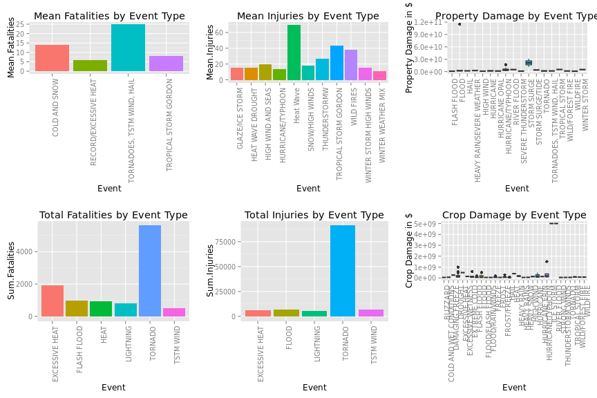

```r
opts_chunk$set(dev = 'pdf')
multiplot(bar.mean.fatalities, bar.sum.fatalities, bar.mean.injuries,
                         bar.sum.injuries, box.property, box.crop, cols=3)
```